# 5장 탐색적 데이터 분석

KIM DONG HO

2020 10 05

# **5.1 들어가기**

이 장에서는 데이터를 체계적으로 탐색하기 위해 시각화 및 탐색을 활용하는 과정을 보여준다. 통계학자들은 이 작업을 탐색적 데이터 분석 또는 간단한 EDA(Exploratory Data Analysis)라고 부르며, EDA는 다음과 같은 반복적인 작업으로 이루어져 있다.

1. 데이터에 대한 질문을 만든다.
2. 데이터를 시각화, 변형 및 모델링하여 질문에 대해 답을 찾는다.
3. 질문을 개선하거나 새로운 질문을 만들기 위해 학습한 방법을 사용한다.

EDA는 엄격한 규칙을 가진 형식적인 과정이 아니다. 무엇보다도 EDA는 사고하는 상태이다. EDA의 초기 단계에서는 떠오르는 모든 아이디어를 마음껏 탐색해야 한다. 아이디어 중 일부는 진행될 것이고, 일부는 난관에 부딪힐 것이다. 이러한 탐색을 지속하면 결국에는 스스로 작성한 것 중 사람들과 소통할 수 있는 몇 가지 생산적인 영역으로 집중하게 될 것이다.

질문이 주어진다고 해도 데이터의 품질은 항상 조사해야 하므로 EDA는 모든 데이터 분석에서 중요한 부분을 차지한다. 데이터 정제는 EDA의 한 가지 적용일 뿐이며 데이터가 여러분의 기대를 충족하는지 질문한다. 데이터를 정제하기 위해서는 EDA의 모든 도구(시각화, 변형 및 모델링)를 사용해야 한다.

## 5.1.1 준비하기

이 장에서는 dplyr과 ggplot2에 대해 배운 내용을 질문하기, 데이터로 답하기 및 새롭게 질문하는 과정과 결합할 것이다.  
library(tidyverse)

# **5.2 질문하기**

판에 박힌 통계적 질문은 없으며 오직 의심스러운 통계적 질문만이 있다.

- 데이빗 콕스

꼼꼼하게 만들어진 잘못된 질문에 대해 정확한 대답을 하는 것보다, 모호하지만 올바른 질문에 근사적인 대답을 하는 것이 훨씬 낫다.

- 존 튜키

**EDA의 목표**는 데이터를 이해하는 것이다.

EDA는 **근본적으로 창의적인 과정**이다. 대부분의 창의적인 과정과 유사하게 좋은 질문을 하는 핵심은 많은 양의 질문을 생성하는 것이다.

탐색을 위해 어떤 질문을 해야 하는가에 대한 규칙은 없다. 그렇지만 데이터에서 발굴할 수 있는 언제나 유용한 두 가지 유형의 질문이 있으며, 다음과 같은 질문들을 시도해 볼 수있다. (78쪽 참고)

1. 변수 내에서 어떤 유형의 변동이 발생하는가?
2. 변수 간에 어떤 유형의 공변동이 발생하는가?

이 장의 남은 부분에서는 이 두 가지 질문에 대해 살펴볼 것이다. **변동**과 **공변동**에 대해 설명하고 각 질문에 대한 몇 가지 답변을 제시할 것이다. 논의를 쉽게 하기 위해 몇 가지 용어를 정의하고자 한다.

**용어 설명**

- **변수(variable)**는 측정할 수 있는 양, 질 또는 속성이다.
- **값(value)**은 변수가 측정될 때의 상태이다. 변수의 값은 측정에 따라 변할 수 있다.
- **관측값(observation)**(또는 사례(case))은 유사한 조건에서 측정된 값들의 집합이다(일반적으로 동시에 같은 대상에 대해 모든 관측된 값을 사용한다.).관측값은 서로 다른 변수가 조합된 다양한 값을 포함한다. 관측값을 데이터 포인트라고 부르기도 한다.
- **테이블 형식의 데이터(Tabular data)**는 각 변수들과 관측값의 조합인 값들의 집합이다. 테이블 형식의 데이터는 각 값은’셀’에, 변수들은 열에, 관측값은 행에 있을 때 타이디(tidy)하다고 한다.

지금까지 보았던 모든 데이터는 타이디 데이터였다. 실제로 데이터 대부분은 타이디하지 않기 때문에 9장에서는 이 부분에 대해 다시 다룰 것이다.

# **5.3 변동**

- 변동(variation)은 변수의 측정값이 변하는 경향을 말한다.
- 범주형 변수도 서로 다른 피실험자(예,다른 사람들의 눈동자색 차이), 또는 다른 시간(예, 다른 순간의 전자의 에너지 수준)을 측정하는 경우, 다를 수 있다.
- 모든 변수는 흥미로운 정보를 나타낼 수 있는 고유한 변동 패턴을 가지고 있으며, 이러한 패턴을 이해하는 가장 좋은 방법은 변수들 값의 분포를 시각화하는 것이다.

## 5.3.1 분포 시각화

- 변수가 범주형인지 연속형인지에 따라 다르다.
- 범주형(categorical) 변수는 유한개의 집합에서 하나의 값만 가질 수 있는 경우
- R에서 범주형 변수는 일반적으로 팩터형이나 문자형 벡터로 저장된다.
- 범주형 변수이 분포를 확인하기 위해서는 막대 그래프를 사용한다.

```r
library(tidyverse)
```

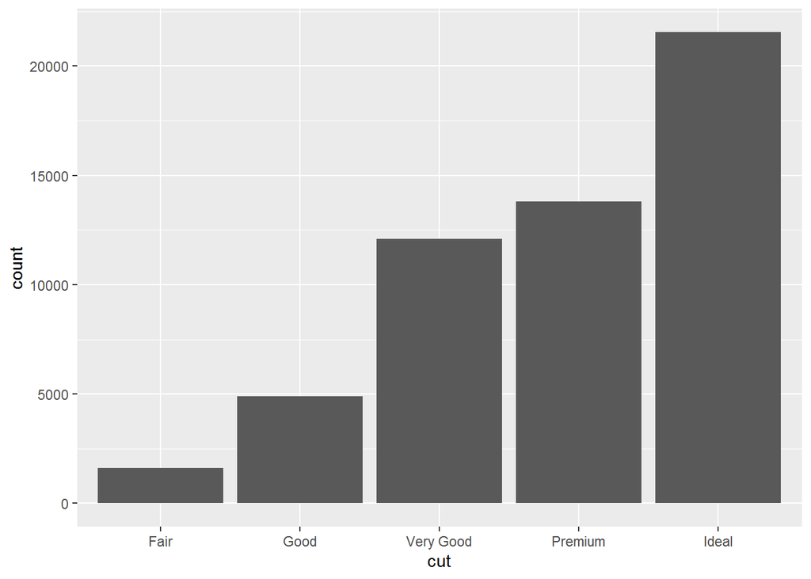

```r
ggplot(data = diamonds) +
  geom_bar(mapping = aes(x = cut))
```

막대의 높이는 각 x값에 대한 관측값의 수를 나타낸다. dplyt::count()를 사용하여 관측값의 수를 수동으로 계산할 수 있다.

```r
diamonds %>%
  count(cut)
```

```
## # A tibble: 5 x 2
##   cut           n
##   <ord>     <int>
## 1 Fair       1610
## 2 Good       4906
## 3 Very Good 12082
## 4 Premium   13791
## 5 Ideal     21551
```

- 연속형(continuous) 변수는 순서가 있는 무한 집합에서 임이의 값을 가질 수 있는 변수
- 숫자와 시간은 연속형 변수의 두 가지 예시이다.
- 연속형 변수의 분포를 확인하기 위해서는 히스토그램을 사용한다.

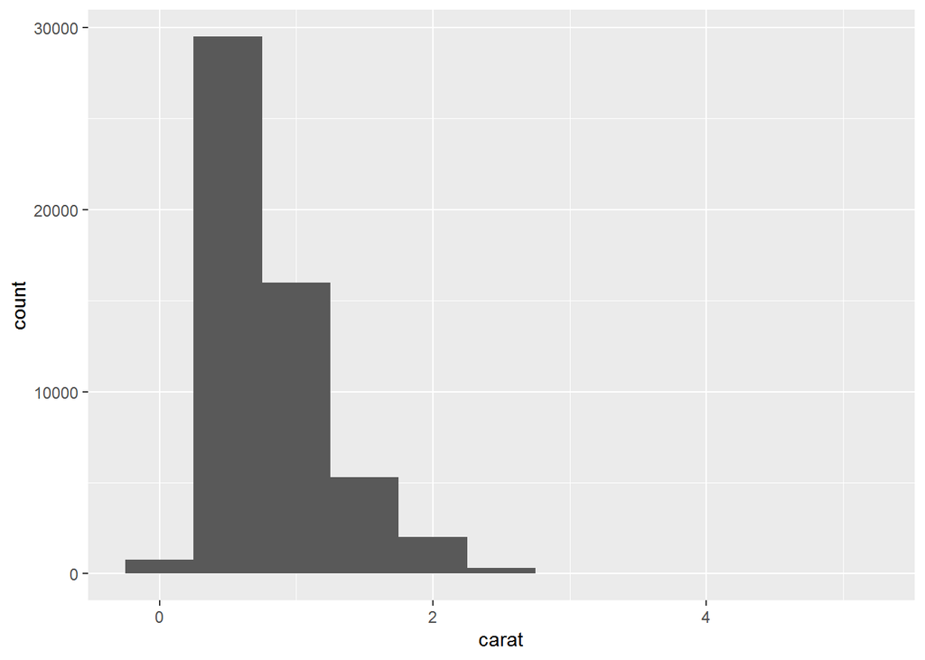

```r
ggplot(data = diamonds) +
  geom_histogram(mapping = aes(x = carat), binwidth = 0.5)
```

dplyr::count()와 ggplot2::cut_width()를 결합하면 값을 직접 계산할 수 있다.

```r
diamonds %>%
  count(cut_width(carat, 0.5))
```

```
## # A tibble: 11 x 2
##    `cut_width(carat, 0.5)`     n
##    <fct>                   <int>
##  1 [-0.25,0.25]              785
##  2 (0.25,0.75]             29498
##  3 (0.75,1.25]             15977
##  4 (1.25,1.75]              5313
##  5 (1.75,2.25]              2002
##  6 (2.25,2.75]               322
##  7 (2.75,3.25]                32
##  8 (3.25,3.75]                 5
##  9 (3.75,4.25]                 4
## 10 (4.25,4.75]                 1
## 11 (4.75,5.25]                 1
```

- 히스토그램은 x축을 동일 간격의 빈(bin)으로 나누고, 각각의 반에 해당하는 관측값의 수를 표시하기 위해 막대의 높이를 사용된다.
- x축 변수의 단위로 측정된 binwidth 인수로 히스토그램 간격의 폭을 설정할 수 있다.
- 빈 너비에 따라 패턴이 달라질 수 있으므로 히스토그램을 사용하여 작업할 때는 항상 다양한 빈 너비를 탐색해야 한다.

  ```
  예를 들어 3캐럿 미만의 다이아몬드로 범위를 줄이고 더 작은 빈 너비를 선택하는 경우, 앞의 그래프가 어떻게 나타나는지 다음의 그래프에서 확인할 수 있다.
  ```

  ```r
  smaller <- diamonds %>%
    filter(carat < 3)
  ```

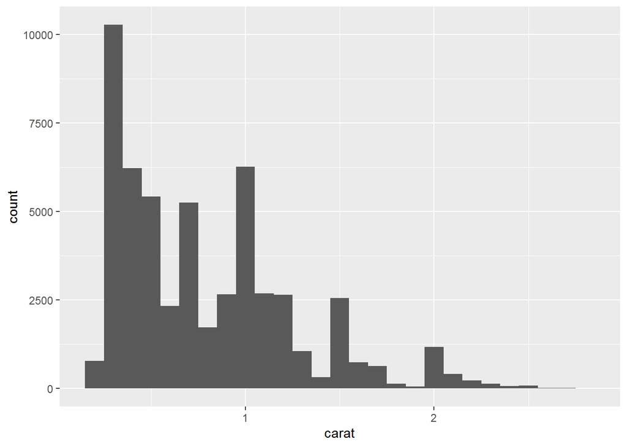

  ```r
  ggplot(data = smaller, mapping = aes(x = carat)) +
    geom_histogram(binwidth = 0.1)
  ```

  - 같은 플롯에 여러 개의 히스토그램을 겹쳐서 그리고 싶다면 **geom_freqpoly()**를 사용하는 것이 좋다.
  - **geom_freqpoly()**는 **geom_histogram()**과 연산은 동일하지만 빈도수를 나타내기 위해 막대가 아닌 선을 사용한다.

  ```
  다음과 같이 막대보다 겹쳐진 선으로 파악하는 것이 훨씬 쉽다.
  ```

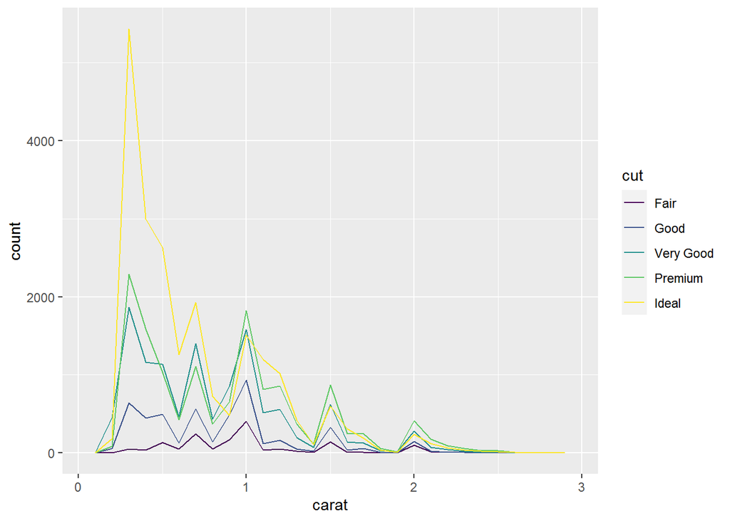

  ```r
  ggplot(dat = smaller, mapping = aes(x = carat, color = cut)) +
    geom_freqpoly(binwidth = 0.1)
  ```

  이러한 유형의 플롯에는 몇 가지 해결해야 할 과제가 있으므로 89쪽의 ’범주형 변수와 연속형 변수’에서 다시 살펴볼 것이다.

## 5.3.2 일반적인 값

- `막대 그래프`와 `히스토그램` 모두 길이가 긴 막대는 빈도가 높은 값을 나타냄

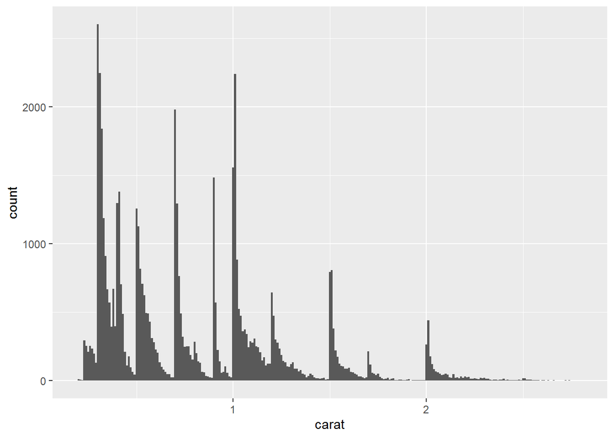

  ```r
  ggplot(data = smaller, mapping = aes(x = carat)) +
    geom_histogram(binwidth = 0.01)
  ```

  일반적으로 유사한 값들의 군집은 데이터 내에 하위집단이 있다는 것을 의미한다. 하위집단을 이해하기 위하여 다음과 같은 질문을 해보자.
  - 각 군집 내의 관측값은 서로 유사한가?
  - 각 군집은 서로 다른 클러스터의 관측값과 다른가?
  - 군집은 어떻게 설명하거나 묘사할 수 있는가?
  - 군집의 모양이 오해의 소지가 있는 이유가 무엇인가?

  ```
  아래 히스토그램은 Yellowstone 국립공원의 Old Faithful Geyser(올드 페이스풀 간헐 온천)에서 발생한 272번의 화산 분출을 분 단위로 나타낸 것이다. 짧은 분출(약 2분)과 긴 분출(4-5분)이 있고, 그 중간에는 값이 거의 없기 때문에 분출 시간은 2개의 그룹으로 묶인 것처럼 보인다.
  ```

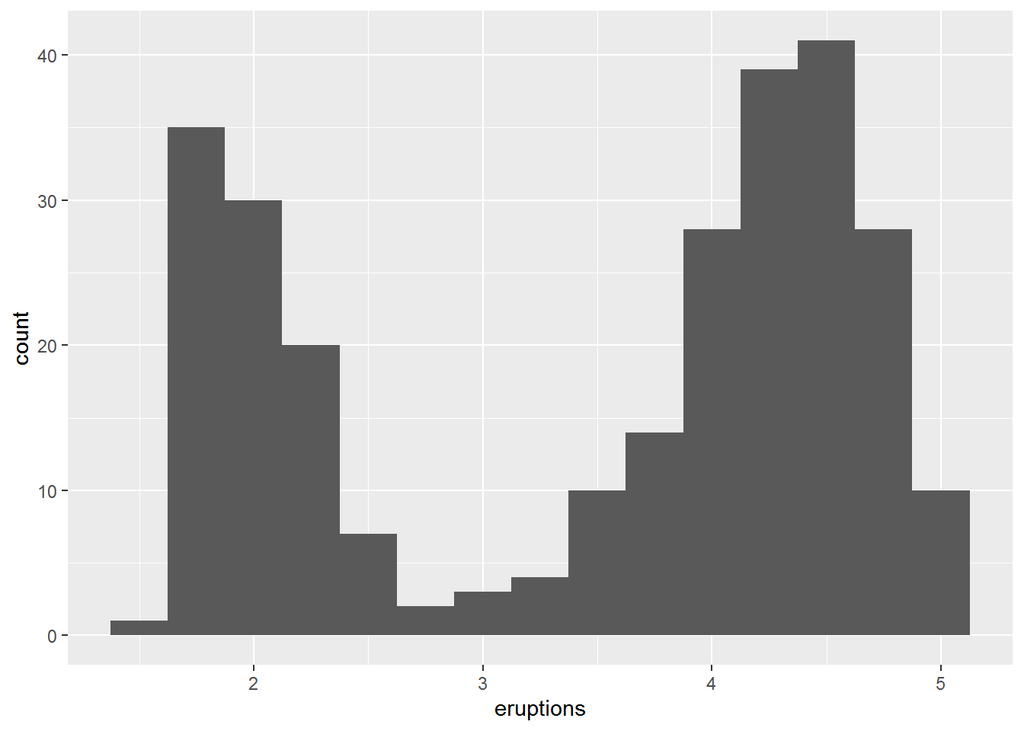

  ```r
  ggplot(data = faithful, mapping = aes(x = eruptions)) +
    geom_histogram(binwidth = 0.25)
  ```

## 5.3.3 이상값

- **이상값**은 패턴과 맞지 않는 데이터 값으로 비정상적인 관측값을 일컫는다.
- 때에 따라 이상값은 데이터 입력 오류이거나 중요하면서 새로운 정보를 제시한다.
- 많은 양의 데이터가 있을 때 히스토그램에서 이상값을 발견하는 것은 어렵다.

[output not shown]

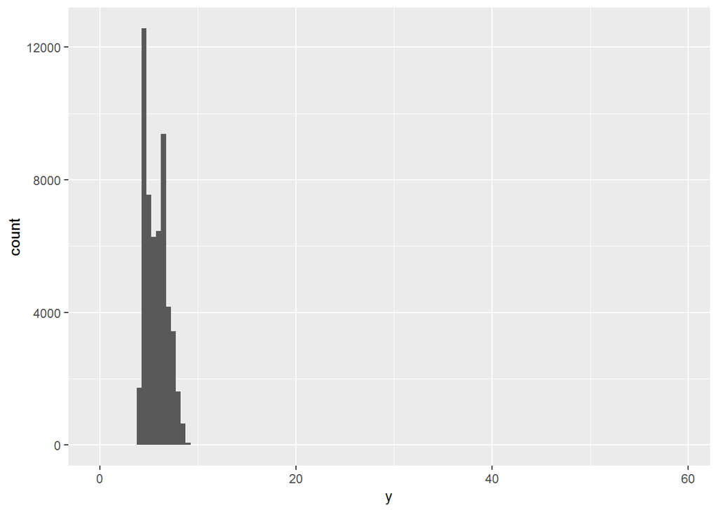

```r
ggplot(diamonds) +
  geom_histogram(mapping = aes(x = y), binwidth =  0.5)
```

- 대부분의 빈에는 많은 관측값이 포함되고 있고, 일부 빈은 길이가 너무 짧아 눈으로 확인하기 어렵다.

```
이상값들을 쉽게 확인하기 위해서는 coord_cartesian()을 사용하여 y축의 작은 값들을 확대해야 한다.
```

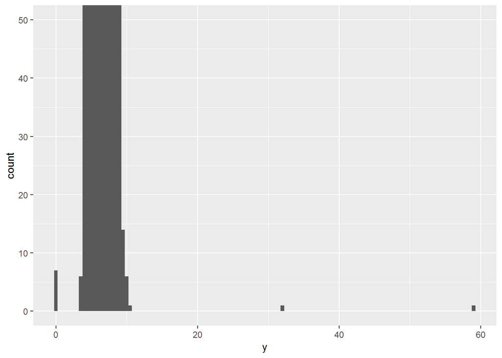

```r
ggplot(diamonds) +
  geom_histogram(mapping = aes(x = y), binwidth = 0.5) +
  coord_cartesian(ylim = c(0, 50))
```

- 세 개의 이상값은 0,~30 및 ~60인 것을 알 수 있으며, 이 값들은 dplyr을 사용하여 추출한다.

```r
unusual <- diamonds %>%
  filter(y < 3 | y > 20) %>%
  select(price, x, y, z) %>%
  arrange(y)
unusual
```

```
## # A tibble: 9 x 4
##   price     x     y     z
##   <int> <dbl> <dbl> <dbl>
## 1  5139  0      0    0
## 2  6381  0      0    0
## 3 12800  0      0    0
## 4 15686  0      0    0
## 5 18034  0      0    0
## 6  2130  0      0    0
## 7  2130  0      0    0
## 8  2075  5.15  31.8  5.12
## 9 12210  8.09  58.9  8.06
```

- 이상값을 포함하거나 제외하여 분석을 반복하는 것은 좋은 연습이다.
- 이상값이 결과에 최소한의 영향을 미치고 왜 이상값이 발생했는지 그 이유를 알 수 없다면 결측값으로 대체한 후 계속 진행하는 것이 합리적이다.
- 문제의 원인(예, 데이터 입력 오류)을 파악하고 이상값을 제거한 사실을 밝혀야 한다.

# **5.4 결측값**

데이터셋에서 이상값을 발견하고 다음 분석으로 넘어가고가 할 때, 다음의 두 가지 옵션이 있다.

- 이상값이 포함된 행 전체를 삭제한다.

  ```r
  diamonds2 <- diamonds %>%
    filter(between(y, 3, 20))
  ```

```r
diamonds2 <- diamonds %>%
  mutate(y < 3 | y > 20, NA, y)
```

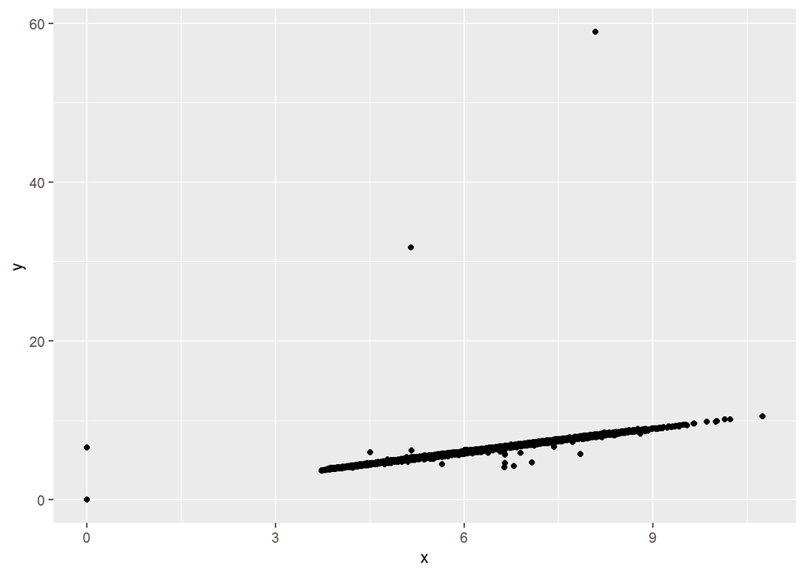

```r
ggplot(data = diamonds2, mapping = aes(x = x, y = y)) +
  geom_point()
```

경고 표시를 숨기려면 na.rm = TRUE로 설정하면 된다.

```
ggplot(data = diamonds2, mapping = aes(x = x, y = y)) +
  geom_point(na.rm = TRUE)
```

때로는 결측값과 기록된 값의 차이를 만드는 것이 무엇인지 알고 싶은 경우가 있다. 예를 들어 취소된 비행기의 예정 출발 시각과 취소되지 않은 비행기의 출발 시각을 비교하고자 한다. is.na()를 사용하여 새로운 변수를 생성하면 이를 수행할 수 있다.

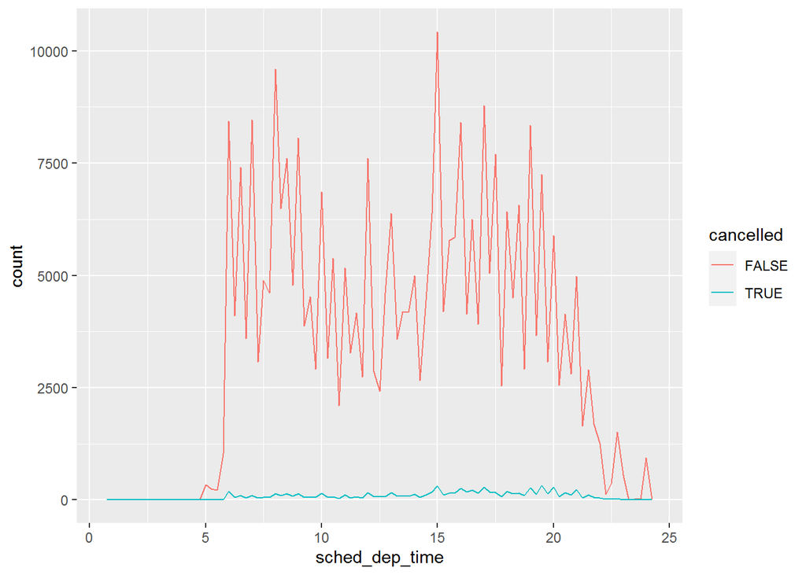

```r
nycflights13::flights %>%
  mutate(
    cancelled = is.na(dep_time),
    sched_hour = sched_dep_time %/% 100,
    sched_min = sched_dep_time %% 100,
    sched_dep_time = sched_hour + sched_min / 60
  ) %>%
  ggplot(mapping = aes(sched_dep_time)) +
  geom_freqpoly(
    mapping = aes(color = cancelled),
    binwidth = 1/4
  )
```

- 취소되지 않은 항공편이 더 많으므로 이 플롯은 유용하지 않다.

# **5.5 공변동**

- **공변동(covariation)**은 변수들 간의 움직임을 설명한다.
- 공변동은 둘 이상의 변숫값이 연관되어 동시에 변하는 경향을 말한다.
- 공변동을 발견하는 가장 좋은 방법은 두 개 이상의 변수 사이의 관계를 시각화하는 것이다.

## 5.5.1 범주형 변수와 연속형 변수

이전의 빈도 다각형과 같이 범주형 변수로 구분된 연속형 변수의 분포를 탐색하고자 하는 것이 일반적이다. geom_freqpoly()이 기본 모양은 높이가 빈도수를 나타내기 때문에 그러한 종류의 비교에는 유용하지 않다. 즉, 그룹 중 하나가 다른 값들보다 월등히 작으면 형태의 차이를 파악하기 어렵다.

```
예를 들어 다이아몬드의 가격이 품질에 따라 어떻게 달라지는지 살펴보자.
```

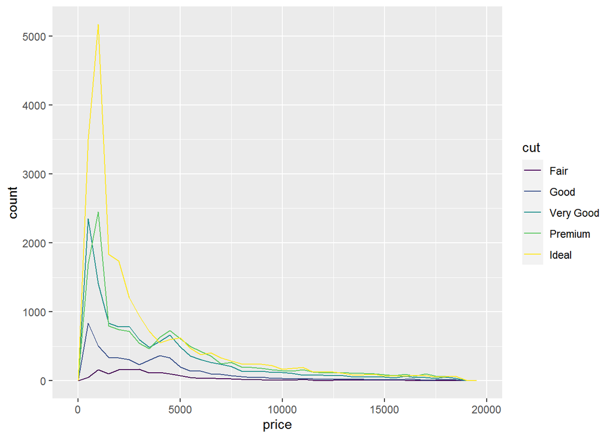

```r
ggplot(data = diamonds, mapping = aes(x = price)) +
  geom_freqpoly(mapping = aes(color = cut), binwidth = 500)
```

전체적인 빈도수가 많이 다르므로 분포의 차이를 파악하기 어렵다.

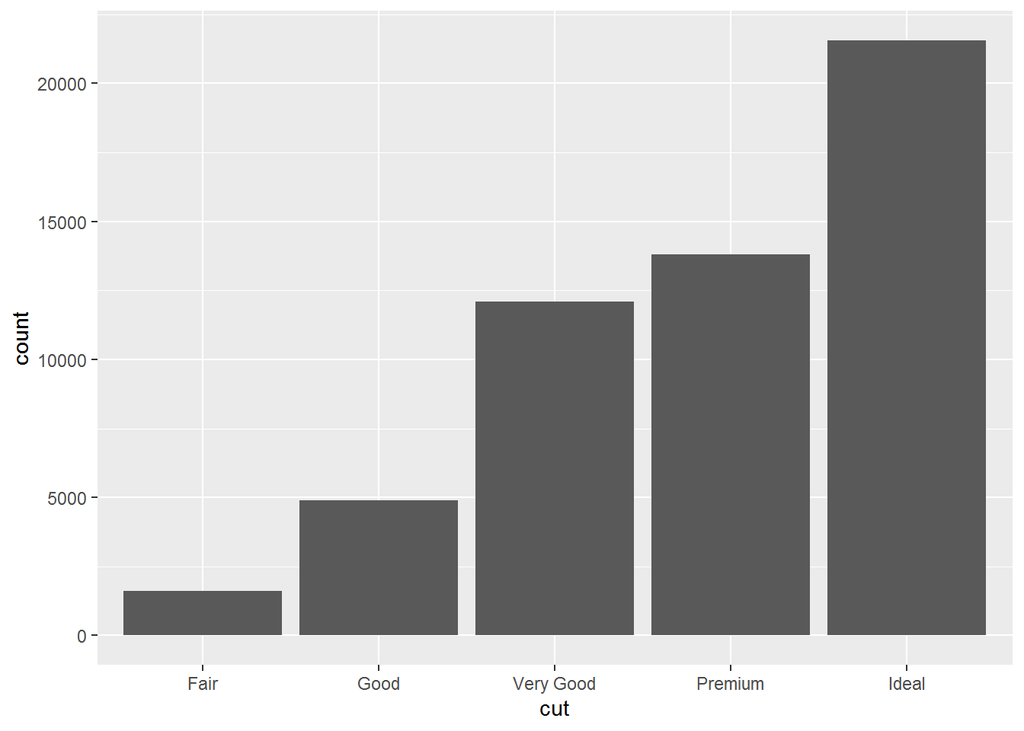

```r
ggplot(diamonds) +
  geom_bar(mapping = aes(x = cut))
```

비교를 쉽게 하기 위해서 y축에 표시된 내용을 변경할 필요가 있다. 빈도수로 나타내는 대신 빈도 다각형 아래의 영역이 1이 되도록 빈도수를 표준화한 밀도로 나타낼 수 있다.

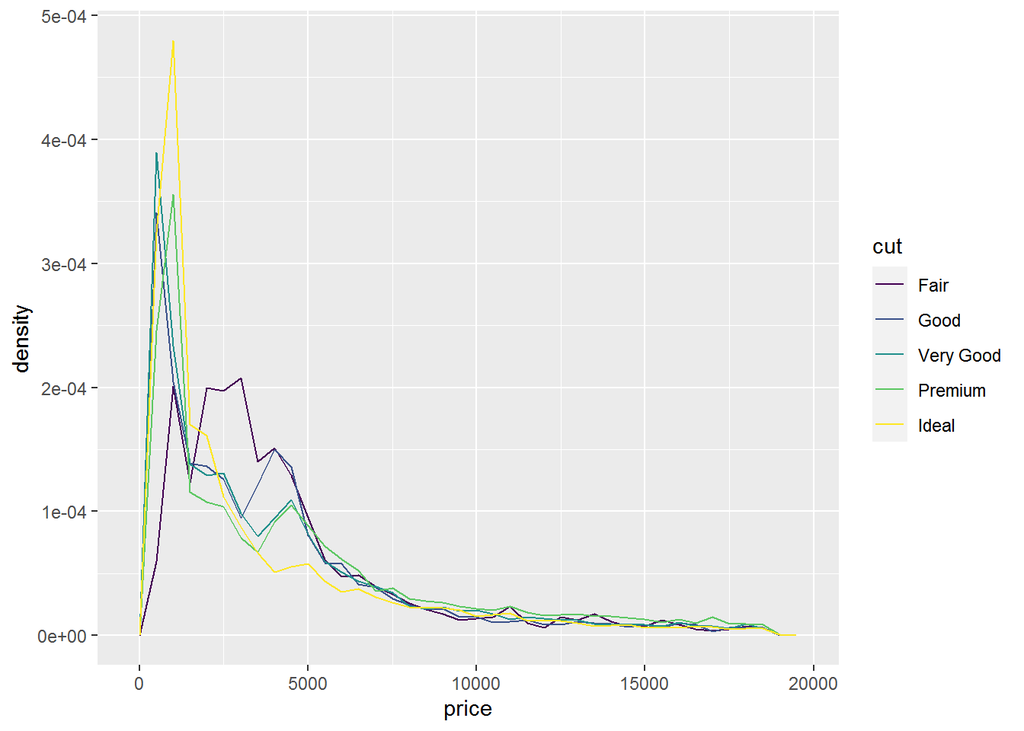

```r
ggplot(
  data = diamonds,
  mapping = aes(x = price, y = ..density..)
) +
  geom_freqpoly(mapping = aes(color = cut), binwidth = 500)
```

- 그것은 fair인 다이아몬드(가장 낮은 품질)가 가장 높은 평균 가격을 가진다는 것이다.

```
-why? 그건 아마도 이 빈도 다각형에는 작업해야 하는 부분이 아직 남아 있어서, 당장은 해석하기가 어렵기 때문일 것이다.
```

범주형 변수로 구분된 연속형 변수의 분포를 나타내는 또 다른 방법은 **박스플롯(boxplot)**이다. 박스 플롯은 값의 분포를 시각적으로 간편하게 보여줄 수 있는 형태로 많은 통계학자가 사용하는 방법이다. 상자 플롯은 다음의 것들로 구성된다.

- 사분위 수 범위(IQR)라고 알려진 길이의 25번째 백분위 수에서 75번째 백분위 수까지 이어진 상자, 분포의 중앙값(즉, 50번째 백분위 수)을 표시하는 상자의 가운데 위치한 선, 이 세 개의 선은 분포의 대략적인 범위와 분포의 중앙값이 대칭인지 또는 한쪽으로 치우쳤는지를 나타낸다.
- 상자의 가장자리에서 1.5배 이상 떨어진 관측값을 나타내는 점, 이렇게 멀리 떨어진 점들은 일반적이지 않기 때문에 개별적으로 표시된다.
- 상자의 양끝에서 뻗어 나와 가장 멀리 떨어진 이상값이 아닌 점까지 이어진 선.

geom_boxplot()을 사용하여 컷팅에 따른 가격 분포

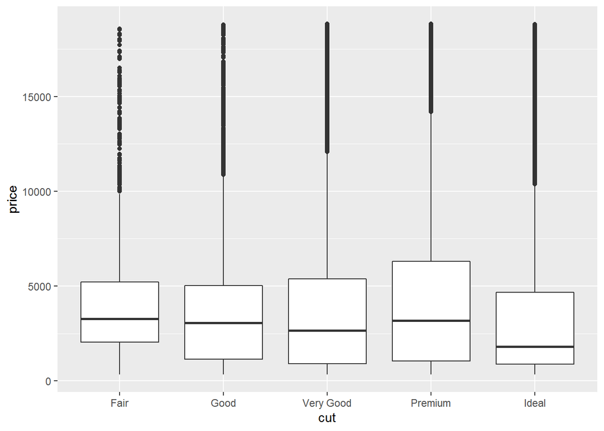

```r
ggplot(data = diamonds, mapping = aes(x = cut, y = price)) +
  geom_boxplot()
```

- 박스 플롯은 분포에 대해 더 적은 정보를 확인 할 수 있으며, 간단하고 쉽게 비교 할 수 있다.
- 이 플롯은 ’더 좋은 품질의 다이아몬드가 평균적으로 더 저렴하다’는 직관에 반하는 사실을 뒷받침한다.
- cut은 순서가 있는 펙터형 변수이다. `fair -> good -> very good 등 순`
- 대부분의 범주형 변수에는 이러한 고유한 순서가 없으므로 순서를 변경하여 더 유용한 정보를 주도록 표현할 수 있는 **reorder()** 함수를 사용하는 것이다.

  ```
  예를 들어 mpg 데이터셋의 class 변수를 살펴보자. 자동차 종류에 따라 고속도로 주행 거리가 어떻게 달라지는지 알아보고자 한다.
  ```

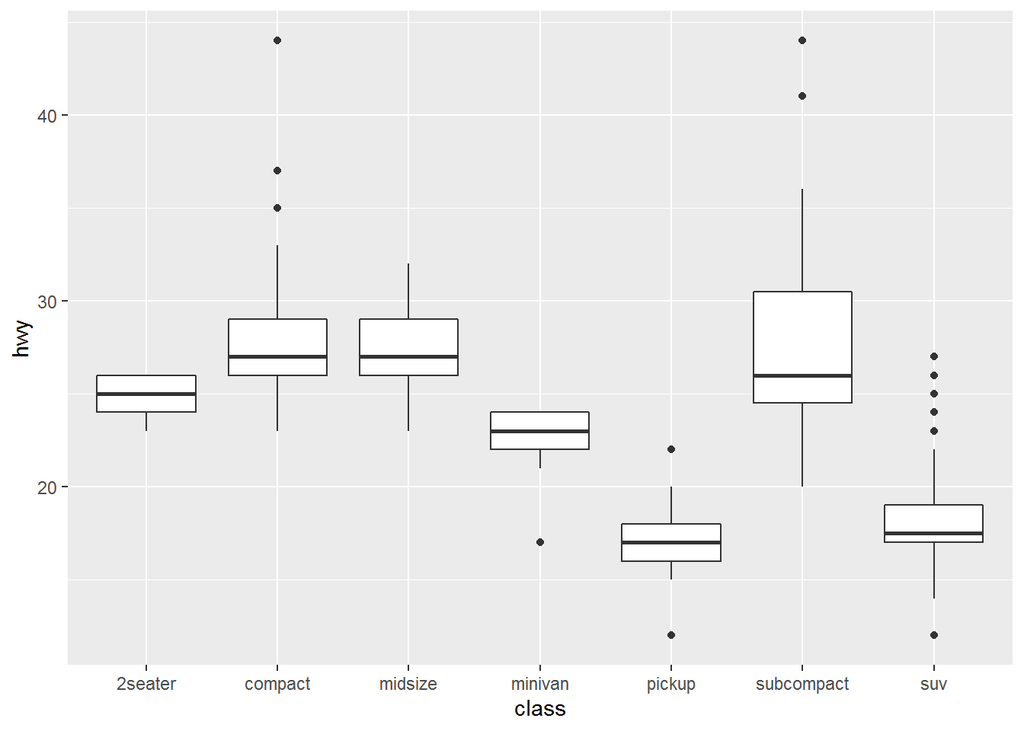

  ```r
  ggplot(data = mpg, mapping = aes(x = class, y = hwy)) +
    geom_boxplot()
  ```

  추세를 더욱 쉽게 파악하기 위해 hwy 변수의 중간값을 기준으로 class 변수의 순서를 변경할 수 있다.

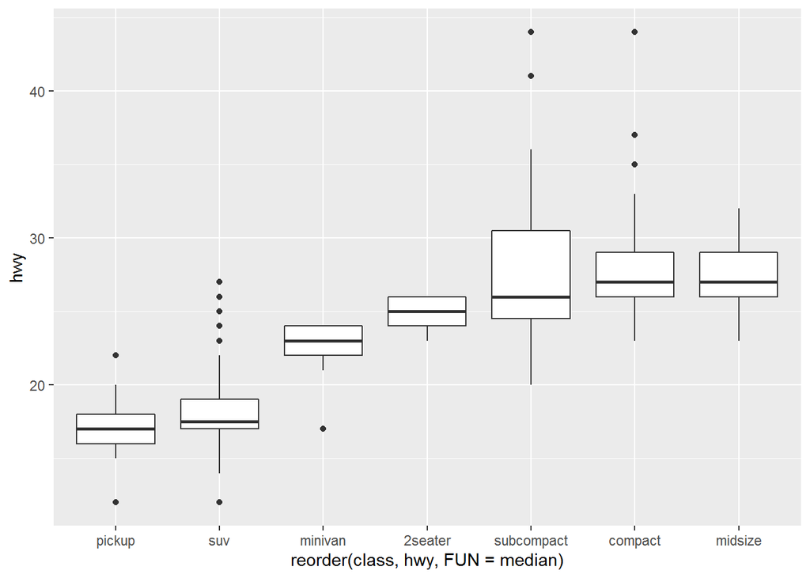

  ```r
  ggplot(data = mpg) +
    geom_boxplot(
      mapping = aes(
        x = reorder(class, hwy, FUN = median),
        y = hwy
      )
    )
  ```

  변수의 이름이 긴 경우 geom_boxplot()90° 회전시키면 더 잘 나타낼 수 있다.

  ```
  coord_flip()을 사용하여 다음과 같이 나타낼 수 있다.
  ```

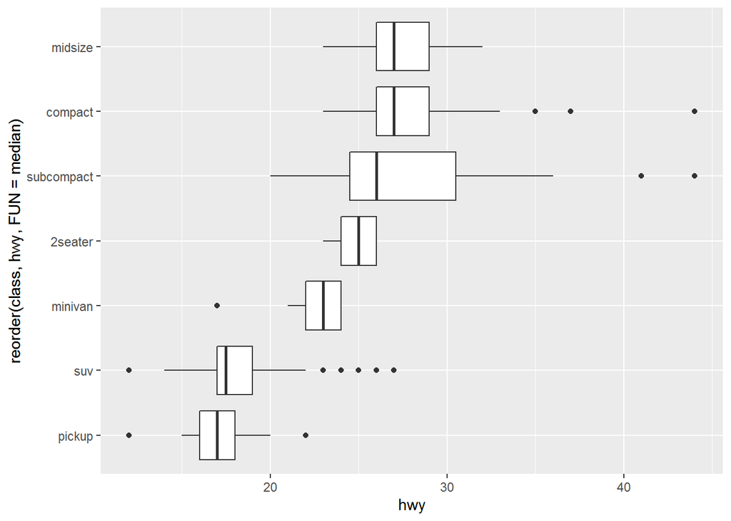

  ```r
  ggplot(data = mpg) +
    geom_boxplot(
      mapping = aes(
        x = reorder(class, hwy, FUN = median),
        y = hwy
      )
    ) +
    coord_flip()
  ```

## 5.5.2 두 개의 범주형 변수

범주형 변수들이 공변동을 시각화하려면 각 조합에 대한 관측값의 수를 세어야 한다. 이를 위한 한 가지 방법은 내장된 함수인 **geom_count()**를 이용하는 것이다.

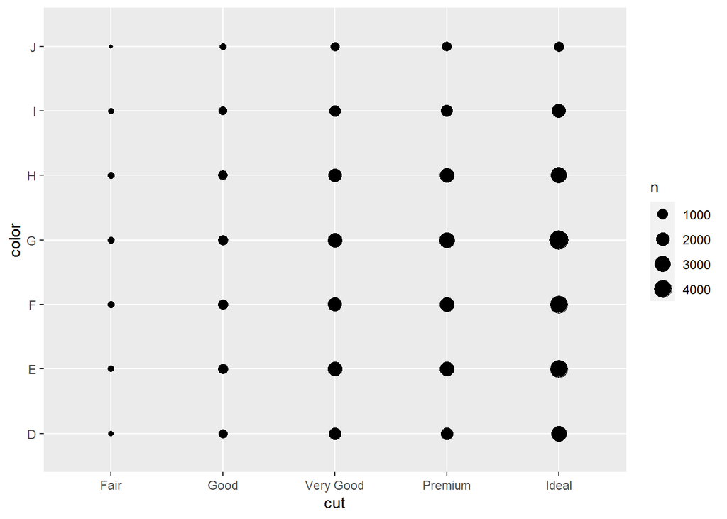

```r
ggplot(data = diamonds) +
  geom_count(mapping = aes(x = cut, y = color))
```

플롯에서 원의 크기는 각 값의 조합에서 발생한 관측값의 수를 나타낸다. 공변동은 특정 x값과 y값 사이에 강한 상관관계로 나타날 것이다.  
또 다른 방법은 dplyr로 빈도수를 계산하는 것이다.

```r
diamonds %>%
  count(color, cut)
```

```
## # A tibble: 35 x 3
##    color cut           n
##    <ord> <ord>     <int>
##  1 D     Fair        163
##  2 D     Good        662
##  3 D     Very Good  1513
##  4 D     Premium    1603
##  5 D     Ideal      2834
##  6 E     Fair        224
##  7 E     Good        933
##  8 E     Very Good  2400
##  9 E     Premium    2337
## 10 E     Ideal      3903
## # ... with 25 more rows
```

그런 다음 geom_tile() 함수와 fill 심미성으로 시각화한다.

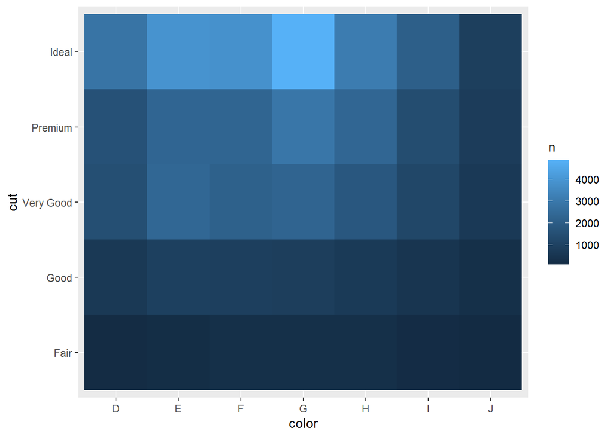

```r
diamonds %>%
  count(color, cut) %>%
  ggplot(mapping = aes(x = color, y = cut)) +
  geom_tile(mapping = aes(fill = n))
```

- 범주형 변수에서 순서가 없는 경우 패턴을 좀 더 명확하게 나타내기 위해 seriation 패키지를 사용하여 행과 열을 동시에 재정렬할 수 있다.

## 5.5.3 두 개의 연속형 변수

두 개의 연속형 변수 사이의 공변동을 시각화하는 좋은 방법 중 하나(geom_point()로 산점도를 그리는 것)는 앞서 배웠다. 점들의 패턴으로 공변동을 확인 할 수 있다.

```
예를 들어 캐럿의 크기와 다이아몬드의 가격 사이에 기하급수적인 관계가 있다는 것을 확인할 수 있다.
```

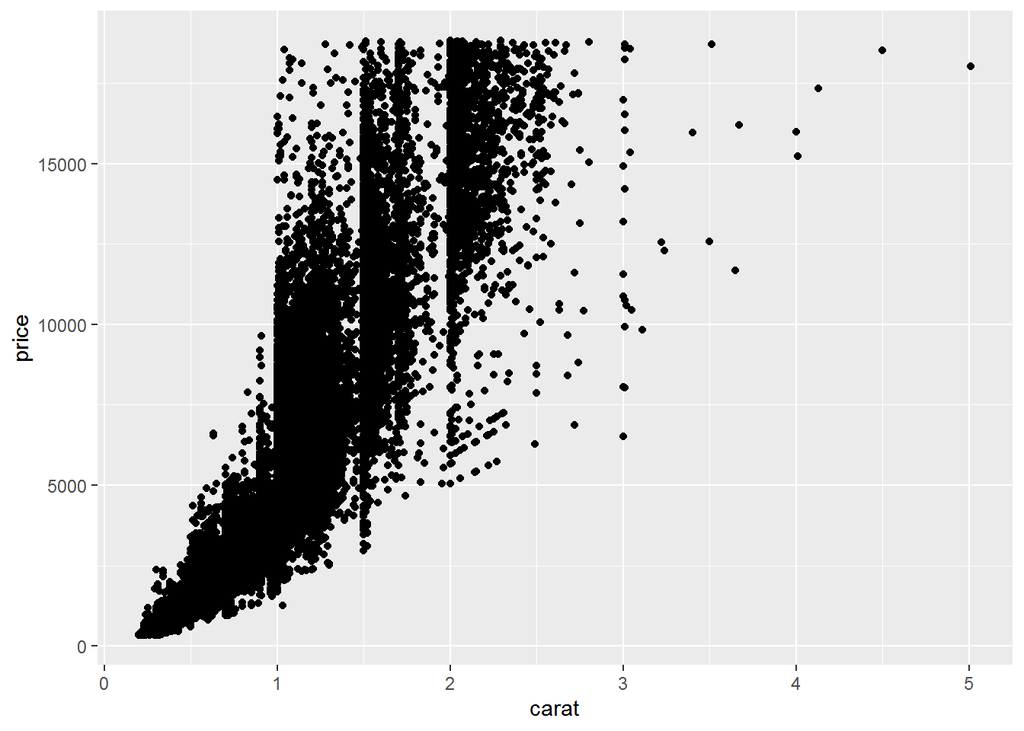

```r
ggplot(data = diamonds) +
  geom_point(mapping = aes(x = carat, y = price))
```

- 산점도는 데이터셋의 크기가 커지면 점들이 겹치고 획일적인 검은색 영역으로 쌓이기 때문에 덜 유용해진다.

  ```
  이러한 문제를 해결하기 위해 alpha 심미성을 사용하여 투명도를 추가하는 방법에 대해서는 앞서 살펴보았다.
  ```

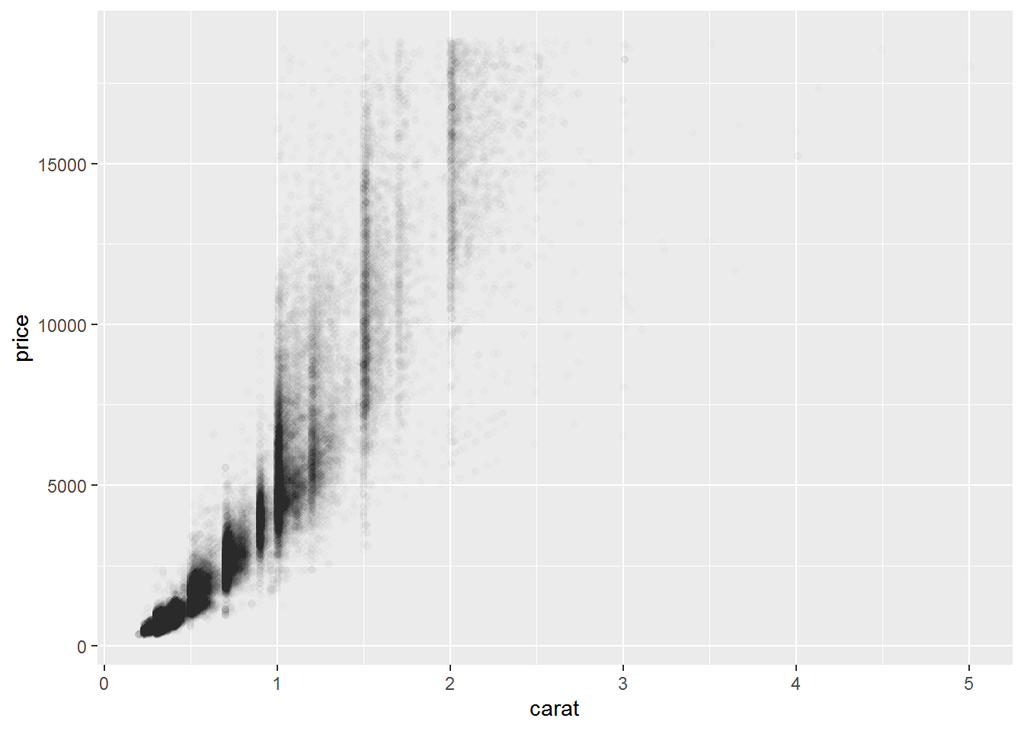

  ```r
  ggplot(data = diamonds) +
    geom_point(
      mapping = aes(x = carat, y = price),
      alpha=1/100
    )
  ```

  - **geom_bin2d()**는 직사각형 빈을 만든다.
  - **geom_hex()**는 육각형 빈을 만든다. `geom_hex()를 사용하기 위해서는 hexbin 패키지를 설치해야 한다.`

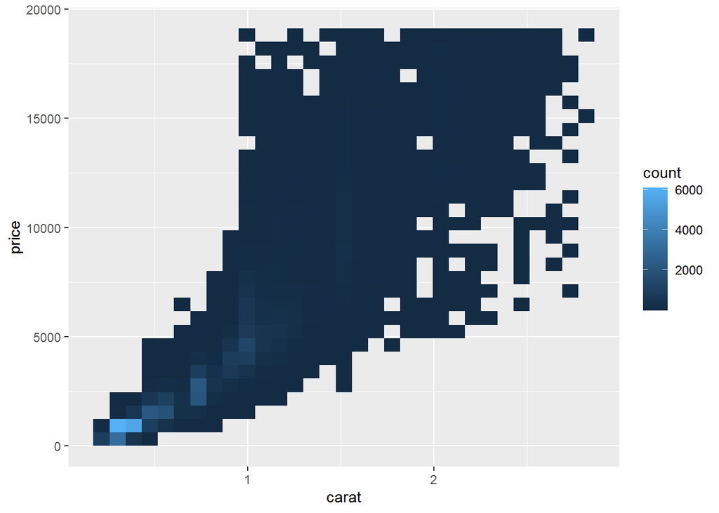

    ```r
    ggplot(data = smaller) +
      geom_bin2d(mapping = aes(x = carat, y = price))
    ```

[figure not shown]

    ```r
    # install.packages("hexbin")
    ggplot(data = smaller) +
      geom_hex(mapping = aes(x = carat, y = price))
    ```

    또 다른 옵션은 하나의 연속 변수를 그룹화하여 범주형 변수처럼 만드는 것이다. 그렇게 하면 이전에 배웠던 범주형 변수와 연속형 변수의 조합을 시각화하는 방법 중 한 가지를 사용할 수 있다. 예를 들어 carat 변수를 그룹화한 후, 각 그룹에 대해 박스 플롯을 그릴 수 있다.

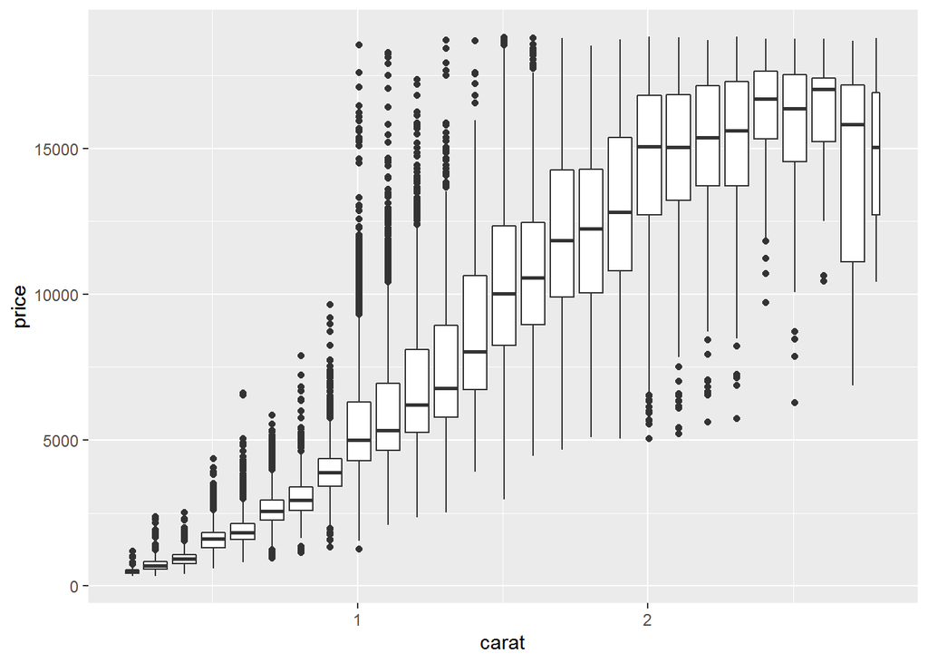

    ```r
    ggplot(data = smaller, mapping = aes(x = carat, y = price)) +
      geom_boxplot(mapping = aes(group = cut_width(carat, 0.1)))
    ```

    여기에서 사용된 cut_width(x, width) 함수는 x를 빈 너비인 width로 나누어준다. 기본적으로 박스 플롯은 (이상값의 수와는 별개로) 얼마나 많은 관측값이 있는 지와 관계없이 동일하게 보이기 때문에 각 박스 플롯이 얼마나 많은 수의 점을 요약하는지는 알기 어렵다. 이를 보여줄 수 있는 한 가지 방법은 varwidth = TRUE를 사용하여 박스 플롯의 너비를 점의 개수와 비례하도록 설정하는 것이다.  
    또 다른 방법은 각 빈에 대략적으로 같은 수의 점을 표시하는 것이다. 이는 **cut_number()**를 사용하면 된다.

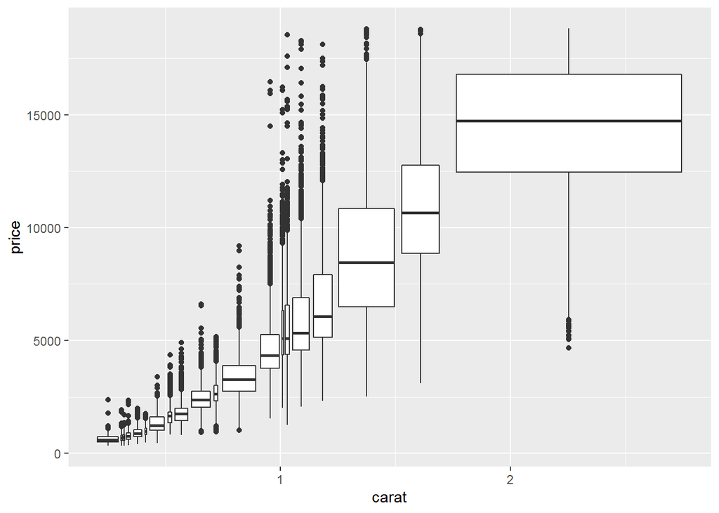

    ```r
    ggplot(data = smaller, mapping = aes(x = carat, y = price)) +
      geom_boxplot(mapping = aes(group = cut_number(carat, 20)))
    ```

# **5.6 패턴과 모델**

데이터의 패턴은 상관관계에 대한 단서를 제공한다. 두 변수 사이에 규칙적인 관계가 존재하면 데이터의 패턴으로 나타난다. 패턴을 발견하게 되면 스스로 질문해보자.

- 이 패턴은 우연의 일치(즉, 랜덤한 가능성)때문인가?
- 패턴이 내포하는 상관관계를 어떻게 설명할 수 있는가?
- 패턴이 내포하는 상관관계는 얼마나 강한가?
- 다른 변수가 그 상관관계에 영향을 줄 수 있는가?
- 데이터의 개별 하위집단을 살펴보면 상관관계가 변경되는가?

Old Faithful 분출 시간과 분출 사이의 시간 사이의 산점도는 분출 사이의 대기 시간이 길수록 분출 시간도 길어지는 패턴을 보인다.

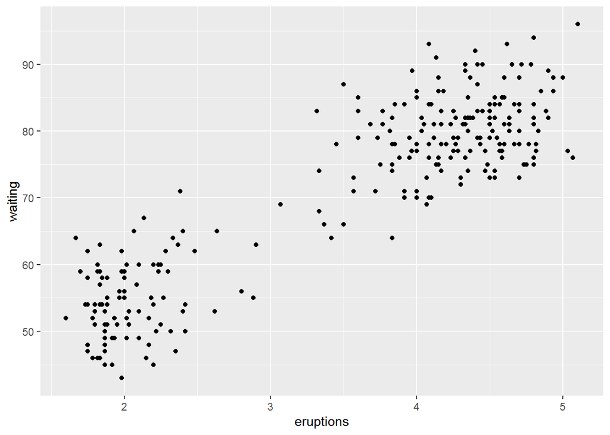

```r
ggplot(data = faithful) +
  geom_point(mapping = aes(x = eruptions, y = waiting))
```

- 패턴은 공변동을 나타내기 때문에 데이터 과학자에게 가장 유용한 도구 중 하나이다.
- 변동을 불확실성이 만드는 현상으로 생각한다면 공변동은 불확실성을 감소시키는 현상이다.
- 두 개의 변수가 함께 변동하면 한 변수의 값을 사용하여 다른 변수의 값을 잘 예측할 수 있다.
- 인과관계(특별한 경우)로 인해 공변동이 생기는 경우, 한 변수의 값을 다른 변수의 값을 통제하는 데 사용할 수 있다.
- 모델은 데이터에서 패턴을 추출하는 도구이다.

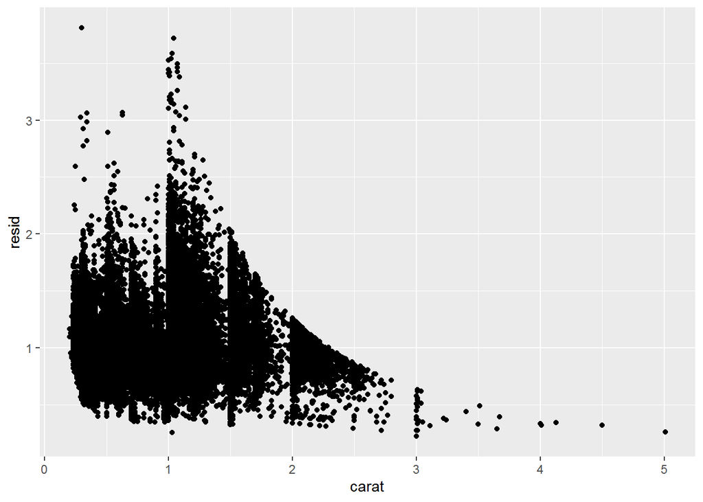

```r
library(modelr)

mod <- lm(log(price) ~ log(carat), data = diamonds)

diamonds2 <- diamonds %>%
  add_residuals(mod) %>%
  mutate(resid = exp(resid))

ggplot(data = diamonds2) +
  geom_point(mapping = aes(x = carat, y = resid))
```

캐럿과 가격의 강한 상관관계를 제거하면 예상할 수 있는 커팅과 가격의 상관관계(다이아몬드의 크기에 비례하여 우수한 품질의 다이아몬드가 더 비싸다)를 파악할 수 있다.

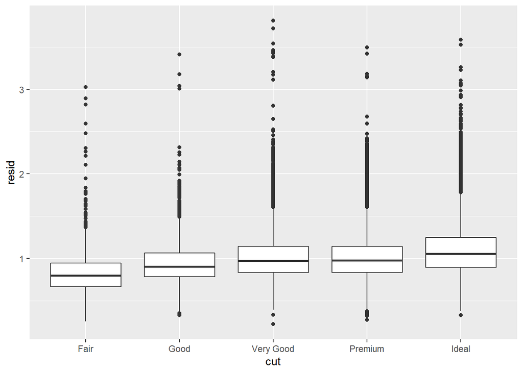

```r
ggplot(data = diamonds2) +
  geom_boxplot(mapping = aes(x = cut, y = resid))
```

이 책의 마지막 부분인 4부에서 모델과 modelr 패키지가 어떻게 작동하는지 배우게 된다. 일단 데이터 처리와 프로그래밍 도구가 익숙해지면 모델이 무엇인지, 어떻게 작동하는지 이해하기 쉬워지므로 모델링에 대해서는 다음에 다루게 될 것이다.

# **5.7 ggplot2 표현**

이 장을 넘어가면 ggplot2 코드 표현을 더 간결하게 바꿀 것이다. 지금까지는 배우는 과정에 도움이 될 수 있도록 명시적인 코드를 사용하였다.

ggplot(data = faithful, mapping = aes(x = eruptions)) +  
geom_freqpoly(binwidth = 0.25)

일반적으로 함수의 첫 번째, 두 번째 인수는 매우 중요하므로 기억해두어야 한다. ggplot()에서 처음 두 개의 인수는 data와 mapping 인수이며, aes()의 처음 두개의 인수는 x와 y이다. 이 책의 나머지 부분에서는 이 이름들을 쓰지 않을 것이다. 이렇게 하면 타이핑이 줄어들고 상용구의 양이 줄어들어 플롯 간에 다른 점을 쉽게 알 수 있다. 이는 15장에서 다루게 될 매우 중요한 프로그래밍 문제이다  
위의 플롯을 좀 더 간결하게 작성하면 다음과 같다.

ggplot(faithful, aes(eruptions)) +  
geom_freqpoly(binwidth = 0.25)

때때로 데이터를 변환하는 파이프라인의 끝을 플롯으로 전환할 것이다. %>%에서 +로 전환되는 것을 유의하자. 이 전환이 필요하지 않기를 바라지만 유감스럽게도 파이프를 발굴하기 이전에 ggplot2가 만들어졌다.  
diamonds %>%  
count(cut, clarity) %>%  
ggplot(aes(clarity, cut, fill = n) +  
geom_tile()

# **결론**

1. geom함수에 따라 시각화의 효과는 달라진다.
2. 데이터와 패턴의 상관관계가 일치해야 한다.
3. 시각화하는 방법은 관련된 변수의 유형에 따라 달라진다.